# Week 5 Exercises

Read the file timeuse_tidy.rds with `readRDS()`. The file contains the dataset that we tidied in the exercise session: records of daily time use from participants over multiple days. Note that since the data has been stored as rds (R-specific format), column types and factor levels are as we left them, and don’t need to be re-corrected.

```r
list.files('C:/Users/eliyuan/Documents/GitHub')
```

```
[1] "datavis-R-2021"
[2] "datavis-R-2022"
[3] "datavis-R-2023"
[4] "datavis-R-2024"
[5] "datavis-R-2026"
[6] "datavis-R-2027"
[7] "https---github.com-Liyuan202-IODS-project.git"
[8] "IODS-project"
[9] "新建文件夹"
```

```r
df <- readRDS('timeuse_tidy.rds') # read the file
df # look at the file
```

| indivID | date | female | age | occ_full_time | activity_class | time_spent | weekday | week_number |
| --- | --- | --- | --- | --- | --- | --- | --- | --- |
| 1013302 | 2016-11-11 | 0 | 70.0 | 0 | Lifts | 0 | Fri | 46 |
| 1013302 | 2016-11-11 | 0 | 70.0 | 0 | Work | 0 | Fri | 46 |
| 1013302 | 2016-11-11 | 0 | 70.0 | 0 | Education | 0 | Fri | 46 |
| 1013302 | 2016-11-11 | 0 | 70.0 | 0 | Shopping | 0 | Fri | 46 |
| 1013302 | 2016-11-11 | 0 | 70.0 | 0 | Business | 0 | Fri | 46 |
| 1013302 | 2016-11-11 | 0 | 70.0 | 0 | Petrol | 0 | Fri | 46 |
| 1013302 | 2016-11-11 | 0 | 70.0 | 0 | Social / Leisure | 0 | Fri | 46 |
| 1013302 | 2016-11-11 | 0 | 70.0 | 0 | Vacation | 0 | Fri | 46 |
| 1013302 | 2016-11-11 | 0 | 70.0 | 0 | Exercise | 6 | Fri | 46 |
| 1013302 | 2016-11-11 | 0 | 70.0 | 0 | Home | 1424 | Fri | 46 |

[output cut: 990 more lines]

# Exercise 1

#### 1.1

Create a new variable that contains combined activity classes: “Work or school” (Work, Business, Education), “Free time” (Shopping, Social / Leisure, Home, Vacation), and “Other”.

Calculate the mean time spent on each of the combined activity classes, grouped by **weekday, participant ID, and occ_full_time**.

```r
# load libraries
library(ggpubr)
library(tidyverse)
library(lubridate)
# Create a new variables 'activity_combined' contains combined activity
df_combine <- df %>%
  mutate(activity_combined = case_when(activity_class %in% c("Work", "Business", "Education") ~ "Work_or_school",
        activity_class %in% c("Shopping", "Social / Leisure", "Home", "Vacation") ~ "Free_time",
       TRUE ~ "Other")) # all other activities will be valued other
# transform the new variable 'activity_combined' to factor variable
df_combine
```

| indivID | date | female | age | occ_full_time | activity_class | time_spent | weekday | week_number | activity_combined |
| --- | --- | --- | --- | --- | --- | --- | --- | --- | --- |
| 1013302 | 2016-11-11 | 0 | 70.0 | 0 | Lifts | 0 | Fri | 46 | Other |
| 1013302 | 2016-11-11 | 0 | 70.0 | 0 | Work | 0 | Fri | 46 | Work_or_school |
| 1013302 | 2016-11-11 | 0 | 70.0 | 0 | Education | 0 | Fri | 46 | Work_or_school |
| 1013302 | 2016-11-11 | 0 | 70.0 | 0 | Shopping | 0 | Fri | 46 | Free_time |
| 1013302 | 2016-11-11 | 0 | 70.0 | 0 | Business | 0 | Fri | 46 | Work_or_school |
| 1013302 | 2016-11-11 | 0 | 70.0 | 0 | Petrol | 0 | Fri | 46 | Other |
| 1013302 | 2016-11-11 | 0 | 70.0 | 0 | Social / Leisure | 0 | Fri | 46 | Free_time |
| 1013302 | 2016-11-11 | 0 | 70.0 | 0 | Vacation | 0 | Fri | 46 | Free_time |
| 1013302 | 2016-11-11 | 0 | 70.0 | 0 | Exercise | 6 | Fri | 46 | Other |
| 1013302 | 2016-11-11 | 0 | 70.0 | 0 | Home | 1424 | Fri | 46 | Free_time |

[output cut: 990 more lines]

```r
df_combine %>%
mutate(activity_combined = factor(activity_combined))
```

| indivID | date | female | age | occ_full_time | activity_class | time_spent | weekday | week_number | activity_combined |
| --- | --- | --- | --- | --- | --- | --- | --- | --- | --- |
| 1013302 | 2016-11-11 | 0 | 70.0 | 0 | Lifts | 0 | Fri | 46 | Other |
| 1013302 | 2016-11-11 | 0 | 70.0 | 0 | Work | 0 | Fri | 46 | Work_or_school |
| 1013302 | 2016-11-11 | 0 | 70.0 | 0 | Education | 0 | Fri | 46 | Work_or_school |
| 1013302 | 2016-11-11 | 0 | 70.0 | 0 | Shopping | 0 | Fri | 46 | Free_time |
| 1013302 | 2016-11-11 | 0 | 70.0 | 0 | Business | 0 | Fri | 46 | Work_or_school |
| 1013302 | 2016-11-11 | 0 | 70.0 | 0 | Petrol | 0 | Fri | 46 | Other |
| 1013302 | 2016-11-11 | 0 | 70.0 | 0 | Social / Leisure | 0 | Fri | 46 | Free_time |
| 1013302 | 2016-11-11 | 0 | 70.0 | 0 | Vacation | 0 | Fri | 46 | Free_time |
| 1013302 | 2016-11-11 | 0 | 70.0 | 0 | Exercise | 6 | Fri | 46 | Other |
| 1013302 | 2016-11-11 | 0 | 70.0 | 0 | Home | 1424 | Fri | 46 | Free_time |

[output cut: 990 more lines]

```r
# Calculate the mean and group
df_new <- df_combine %>%
  group_by(weekday, indivID, occ_full_time) %>%
  mutate(time_spent = mean(time_spent),
         n = n()) %>%
  ungroup()
df_new
```

| indivID | date | female | age | occ_full_time | activity_class | time_spent | weekday | week_number | activity_combined | n |
| --- | --- | --- | --- | --- | --- | --- | --- | --- | --- | --- |
| 1013302 | 2016-11-11 | 0 | 70.0 | 0 | Lifts | 120 | Fri | 46 | Other | 24 |
| 1013302 | 2016-11-11 | 0 | 70.0 | 0 | Work | 120 | Fri | 46 | Work_or_school | 24 |
| 1013302 | 2016-11-11 | 0 | 70.0 | 0 | Education | 120 | Fri | 46 | Work_or_school | 24 |
| 1013302 | 2016-11-11 | 0 | 70.0 | 0 | Shopping | 120 | Fri | 46 | Free_time | 24 |
| 1013302 | 2016-11-11 | 0 | 70.0 | 0 | Business | 120 | Fri | 46 | Work_or_school | 24 |
| 1013302 | 2016-11-11 | 0 | 70.0 | 0 | Petrol | 120 | Fri | 46 | Other | 24 |
| 1013302 | 2016-11-11 | 0 | 70.0 | 0 | Social / Leisure | 120 | Fri | 46 | Free_time | 24 |
| 1013302 | 2016-11-11 | 0 | 70.0 | 0 | Vacation | 120 | Fri | 46 | Free_time | 24 |
| 1013302 | 2016-11-11 | 0 | 70.0 | 0 | Exercise | 120 | Fri | 46 | Other | 24 |
| 1013302 | 2016-11-11 | 0 | 70.0 | 0 | Home | 120 | Fri | 46 | Free_time | 24 |

[output cut: 990 more lines]

#### 1.2

Visualise the means you calculated.

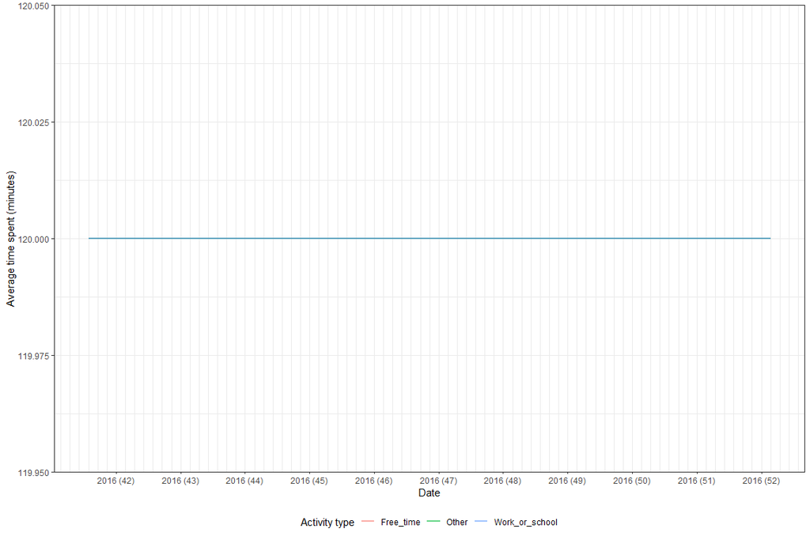

```r
df_new %>%
ggplot(aes(date, time_spent, color = activity_combined)) +
  geom_line(size = 1, alpha = .6) +
  scale_x_date(date_breaks = "1 week", date_labels = "%Y (%W)", date_minor_breaks = "1 day") +
  labs(x = "Date", y = "Average time spent (minutes)", colour = "Activity type") +
  theme_bw() +
  theme(legend.position = "bottom")
```

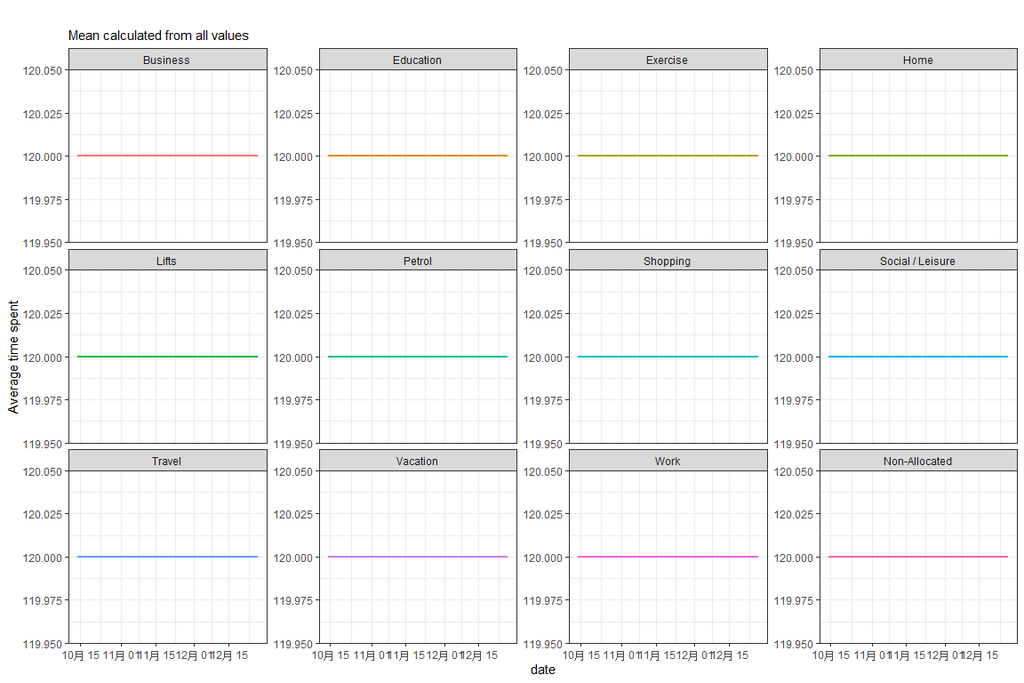

```r
df_new %>%
  ggplot(aes(date, time_spent, color = activity_class, group=1)) + geom_line(size=1) +
  facet_wrap(~activity_class, scales = "free_y") +
  labs(x = "date", y = "Average time spent", colour = "Activity type", title = " ",
       subtitle = "Mean calculated from all values") + theme_bw() +
  theme(legend.position = "none")
```

[figure not shown]

```r
df_new %>%
  ggplot(aes(time_spent)) + geom_density() +
  labs(x = "Time spent (minutes)", title = "Distribution of all records") +
  theme_bw()
```

# Exercise 2

#### 2.1

What is computed in the code chunk below - what do the numbers tell you?

Can you think of another way to calculate the same thing?

```r
# The command means keeping only indivID and data in the data frame, arrange by the number of observations in ascending order by date, count observations by date. And the results means how many participants in the date, and the date is in ascending order.
```

```r
df_new %>%
  distinct(indivID, date) %>%
  arrange(date) %>%
  count(date)
```

| date | n |
| --- | --- |
| 2016-10-14 | 6 |
| 2016-10-15 | 11 |
| 2016-10-16 | 10 |
| 2016-10-17 | 10 |
| 2016-10-18 | 14 |
| 2016-10-19 | 16 |
| 2016-10-20 | 11 |
| 2016-10-21 | 11 |
| 2016-10-22 | 17 |
| 2016-10-23 | 18 |

[output cut: 63 more lines]

```r
# Other way (need to go back and see what others)
df_new_new <- df_new %>%
  select(c(indivID, date)) %>%
  group_by(date) %>%
  summarise(n = n_distinct(indivID))
df_new_new
```

| date | n |
| --- | --- |
| 2016-10-14 | 6 |
| 2016-10-15 | 11 |
| 2016-10-16 | 10 |
| 2016-10-17 | 10 |
| 2016-10-18 | 14 |
| 2016-10-19 | 16 |
| 2016-10-20 | 11 |
| 2016-10-21 | 11 |
| 2016-10-22 | 17 |
| 2016-10-23 | 18 |

[output cut: 63 more lines]

#### 2.2

Plot the numbers from above (use points, lines, or whatever you think is suitable).

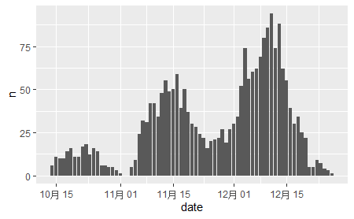

```r
df_new_new %>%
  ggplot(aes(x = date, y = n)) +
  geom_col(position = "dodge")
```

# Exercise 3

#### 3.1

[output not shown]

[output cut: 346 more lines]

#### 3.2

For each participant, count the **number of separate days** that they recorded their time use on.

```r
df_new %>%
  group_by(indivID, .drop = FALSE) %>%
  summarise(date) %>%
  count(date) %>%
  ungroup()
```

| indivID | date | n |
| --- | --- | --- |
| 1013302 | 2016-11-11 | 12 |
| 1013302 | 2016-11-12 | 12 |
| 1013302 | 2016-11-13 | 12 |
| 1013302 | 2016-11-14 | 12 |
| 1013302 | 2016-11-15 | 12 |
| 1013302 | 2016-11-16 | 12 |
| 1013302 | 2016-11-18 | 12 |
| 1013302 | 2016-11-19 | 12 |
| 1013302 | 2016-11-20 | 12 |
| 1013302 | 2016-11-22 | 12 |

[output cut: 990 more lines]

# Exercise 4

Explain step by step what happens in the code chunk below, and what the final figure represents.

```r
# The final figure represents that: x is date and y is participants; the same participants showed in the different date. And the different month have different color, so there are three months.The line have different points, one line present one participant, and one point present one date, thus one participants would be in different dates.
```

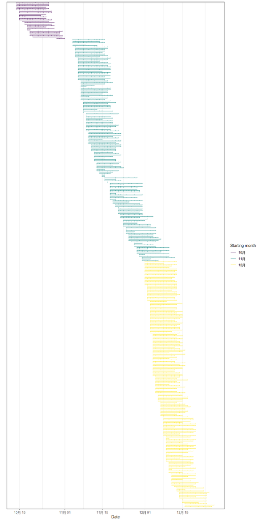

```r
df_new %>%
  group_by(indivID) %>% # group by indivID
  mutate(start_date = min(date)) %>% #calculate the min of date
  ungroup %>% # ungroup the group by indivID above
  mutate(indivID = factor(indivID), # change indivID to factor variable
         indivID = fct_reorder(indivID, start_date) %>% fct_rev()) %>% # reorder and reverse the order
  ggplot(aes(date, indivID, colour = month(start_date, label = T))) +  # x axis is date, y axis is indivID, and colour will depend on month
  geom_line() + # draw a line
  geom_point(size=.5, alpha=.1) + # used to create scatterplots
  theme_bw() + # simple black and white theme
  scale_y_discrete(breaks = "none") +
  labs(x = "Date", y = "", colour = "Starting month") # name x "Date", and use "Starting month" as different color
```